# Model_3_Report

SM

2023-10-11

## Educational Mobile Game Vs. Educational Board Game

We analyze if the school should invest in mobile game or board game to improve nutrition knowledge of secondary students. Our aim is to identify the option with higher monetary value and learning effect- likelihood of wider knowledge dissemination and likelihood of behavioral change.

The decision makers for this intervention are the school authorities, and the stakeholders are students, parents, and other players of mobile and board games. The impact pathway model for decision analysis is shown below.

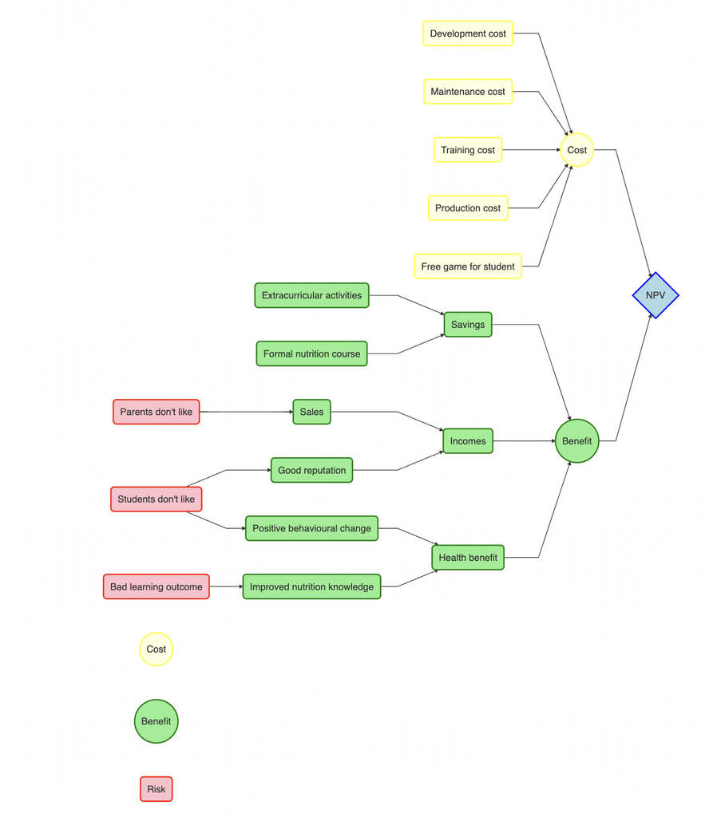

Figure: Impact Pathway Model of Educational Game Intervention